# dev2_ComptesProportion

Mamadou Billo Diallo

2023-09-15

# Tâche 1 : Réflexion

Mettez votre réflexion ici des lectures sur les comptes et proportions il est important d’utiliser comptes et les proportions dans nos visualisations car elles nous permettent de visualisé les données en entier sans ambiguité.les comptes peuvent aider à résumer des données brutes en comptant le nombre d’occurrences de chaque catégorie ou élément. pour une analyse descriptive Ils permettent de répondre à des questions simples telles que “Combien de fois cela s’est-il produit ?” Les proportions sont aussi comme des comptes exprimés en pourcentage par rapport à un total. Ils sont particulièrement utiles pour comparer des sous-groupes par rapport à l’ensemble des données. Par exemple, vous pouvez comparer la proportion de personnes préférant un certain type de nourriture dans différentes régions.

# Tâche 2 : Construction pandémique essentielle

## Charger et nettoyer les données

Nous chargeons et nettoyons d’abord les données (téléchargées en mai 2020, vous pouvez aller charger des données plus récentes!):

```r
# Vous n'aurez besoin que de la bibliothèque tidyverse pour cet exercice
library(tidyverse)
# Charger les données d'origine
essential_raw <- read_csv("data/EssentialConstruction.csv",
                          show_col_types = FALSE)

# Nettoyer un peu les données
# Certains noms d'arrondissements sont en MAJUSCULES, nous utilisons donc str_to_title() pour convertir
# tout dans la colonne
# Nous faisons également des facteurs ARRONDISSEMENT et CATÉGORIE (ou variables catégorielles)
essentiel <- essential_raw %>%
  mutate(BOROUGH = str_to_title(BOROUGH),
         BOROUGH = factor(BOROUGH),
         CATEGORY = factor(CATEGORY))
```

```r
essential_raw
```

```
## # A tibble: 7,209 × 7
##    ADDRESS                BOROUGH     BIN    CD CATEGORY         SUBCA…¹ JOB N…²
##    <chr>                  <chr>     <dbl> <dbl> <chr>            <chr>   <chr>
##  1 1074 WASHINGTON AVENUE Bronx   2129119   203 Affordable Hous… <NA>    All jo…
##  2 1115 EAST 165TH STREET Bronx   2129161   202 Affordable Hous… <NA>    All jo…
##  3 112 EAST CLARKE PLACE  Bronx   2129183   204 Affordable Hous… <NA>    All jo…
##  4 1164 RIVER AVENUE      Bronx   2130367   204 Affordable Hous… <NA>    All jo…
##  5 1193 FULTON AVENUE     BRONX   2004216   203 Affordable Hous… <NA>    All jo…
##  6 1193 FULTON AVENUE     Bronx   2129503   203 Affordable Hous… <NA>    All jo…
##  7 1201 SPOFFORD AVENUE   BRONX   2005938   202 Affordable Hous… <NA>    All jo…
##  8 1230 METCALF AVENUE    Bronx   2025407   209 Affordable Hous… <NA>    All jo…
##  9 1240 GERARD AVENUE     Bronx   2103799   204 Affordable Hous… <NA>    All jo…
## 10 1325 JEROME AVENUE     Bronx   2129224   204 Affordable Hous… <NA>    All jo…
## # … with 7,199 more rows, and abbreviated variable names ¹SUBCATEGORIES,
## #   ²`JOB NUMBERS`
```

## Projets approuvés par arrondissement

À l’heure actuelle, il y a une ligne pour chaque chantier de construction approuvé. Nous devons condenser cela pour obtenir le nombre de chantiers de construction selon différentes variables. Nous pouvons le faire en utilisant `group_by()` et `summarize()`

```r
essentiel_par_arrondissement <- essentiel %>%
  group_by(BOROUGH) %>%
  summarise(total = n()) %>%
  mutate(proportion = total / sum(total))
```

```r
essentiel_par_arrondissement
```

```
## # A tibble: 5 × 3
##   BOROUGH       total proportion
##   <fct>         <int>      <dbl>
## 1 Bronx          1169     0.162
## 2 Brooklyn       2231     0.309
## 3 Manhattan      2420     0.336
## 4 Queens         1135     0.157
## 5 Staten Island   254     0.0352
```

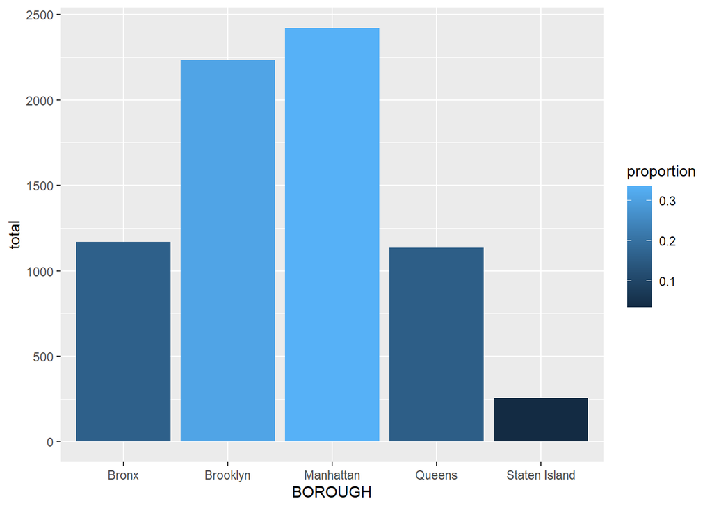

```r
# Ajouter un graphique avec geom_col() ici
ggplot(data = essentiel_par_arrondissement,mapping = aes(x=BOROUGH,y=total,fill=proportion))+
  geom_col(position=position_dodge())
```

## Projets approuvés par catégorie

```r
# Créer un jeu de données résumé des projets par catégorie
#
# Je ne vous donnerai pas le code pour cela (gros indice cependant : copiez le code pour le
# résumé d'arrondissement et ne changer qu'une chose)
essentiel_par_CATEGORY <- essentiel %>%
  group_by(CATEGORY) %>%
  summarise(total = n()) %>%
  mutate(proportion = total / sum(total))
```

```r
essentiel_par_CATEGORY
```

```
## # A tibble: 7 × 3
##   CATEGORY               total proportion
##   <fct>                  <int>      <dbl>
## 1 Affordable Housing       372   0.0516
## 2 Approved Work           4189   0.581
## 3 Homeless Shelter           5   0.000694
## 4 Hospital / Health Care   259   0.0359
## 5 Public Housing          1014   0.141
## 6 Schools                 1280   0.178
## 7 Utility                   90   0.0125
```

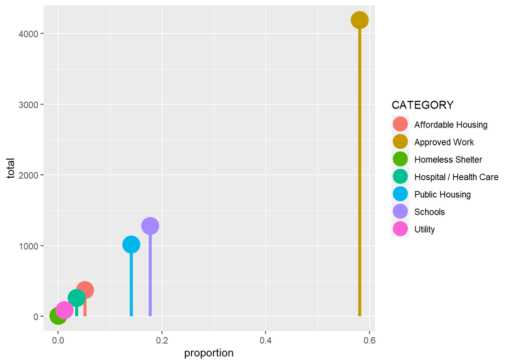

```r
# Ajoutez un graphique en forme de sucette (lollipop) ici

ggplot(data = essentiel_par_CATEGORY,
 mapping = aes(x = proportion, y = total, color = CATEGORY)) +
 geom_pointrange(aes(ymin = 0, ymax = total),
 # Rendre les lignes un peu plus épaisses et les points un peu plus gros
 fatten = 5, size = 1.5)
```

## Projets approuvés dans l’arrondissement et la catégorie

```r
# Créer un ensemble de données résumé des projets par arrondissement et par catégorie
#
# Je ne vous donnerai pas non plus le code pour faire le résumé de la heatmap. Vous avez
# besoin de grouper par deux variables pour faire le résumé. IMPORTANT, vous aurez également
# besoin d'ajouter un autre group_by() entre summarise() et mutate(), sinon,
# R calculera des pourcentages dans des groupes inattendus.
#
# Si vous voulez que les pourcentages des catégories s'additionnent à 100% dans chaque arrondissement,
# vous voudrez grouper par arrondissement avant de calculer la proportion ; si tu veux
# les pourcentages d'arrondissements à additionner jusqu'à 100% dans chaque catégorie, vous voudrez
# groupe par catégorie


essentiel_par_arrondissement_et_category<- essentiel %>%
  group_by(BOROUGH,CATEGORY) %>%
  summarise(total = n()) %>%
  group_by(CATEGORY)%>%
  mutate(proportion = total / sum(total))
essentiel_par_arrondissement_et_category
```

```
## # A tibble: 33 × 4
## # Groups:   CATEGORY [7]
##    BOROUGH  CATEGORY               total proportion
##    <fct>    <fct>                  <int>      <dbl>
##  1 Bronx    Affordable Housing        80      0.215
##  2 Bronx    Approved Work            518      0.124
##  3 Bronx    Homeless Shelter           1      0.2
##  4 Bronx    Hospital / Health Care    55      0.212
##  5 Bronx    Public Housing           276      0.272
##  6 Bronx    Schools                  229      0.179
##  7 Bronx    Utility                   10      0.111
##  8 Brooklyn Affordable Housing       168      0.452
##  9 Brooklyn Approved Work           1223      0.292
## 10 Brooklyn Hospital / Health Care    66      0.255
## # … with 23 more rows
```

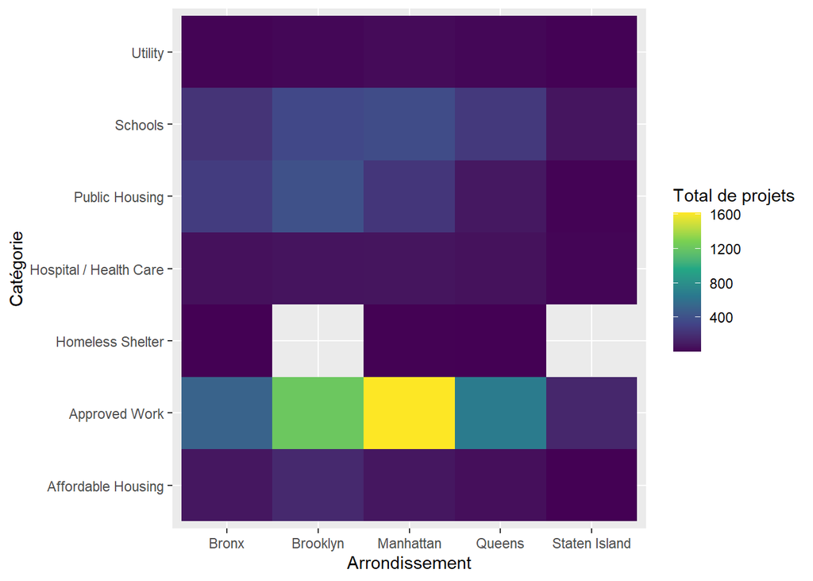

```r
# Ajoutez une heatmap ici avec geom_tile()


ggplot(data = essentiel_par_arrondissement_et_category,
       mapping = aes(x = BOROUGH, y = CATEGORY, fill = total)) +
  geom_tile() +
  labs(
    x = "Arrondissement",
    y = "Catégorie",
    fill = "Total de projets"
  ) +
   scale_fill_viridis_c()
```